# Выбор гипотезы и анализ А/В теста для интернет-магазина

**Заказчик:** интернет-магазин

**Цель проекта:** выбрать гипотезу из списка улучшений от отдела маркетинга и проверить помогает ли выбранное изменение повысить выручку.

**Основные шаги:**

- проведем приоритизацию гипотез, с использованием фреймворков ICE и RICE
- проведем A/B-тест и анализ результатов.

## Загрузка и предобработка данных

### Описание данных

Файл hypothesis.csv содержит информацию о 9 гипотезах по увеличению выручки интернет-магазина с указанными параметрами `Reach`, `Impact`, `Confidence`, `Effort`. \ `hypothesis.csv`:

```
Hypothesis — краткое описание гипотезы;
Reach — охват пользователей по 10-балльной шкале;
Impact — влияние на пользователей по 10-балльной шкале;
Confidence — уверенность в гипотезе по 10-балльной шкале;
Efforts — затраты ресурсов на проверку гипотезы по 10-балльной шкале. Чем больше значение Efforts, тем дороже проверка гипотезы.
```

В файлах orders.csv и visitors.csv содержится информация о результатах А/В теста.  
`orders.csv`:

```
transactionId — идентификатор заказа;
visitorId — идентификатор пользователя, совершившего заказ;
date — дата, когда был совершён заказ;
revenue — выручка заказа;
group — группа A/B-теста, в которую попал заказ.
```

`visitors.csv`:

```
date — дата;
group — группа A/B-теста;
visitors — количество пользователей в указанную дату в указанной группе A/B-теста
```

### Чтение данных

```python
# импортируем библиотеки
import pandas as pd
import numpy as np
import math as mth
from datetime import datetime
from matplotlib import pyplot as plt
from scipy import stats as st
```

```python
# отключаем предупреждения
import warnings
warnings.filterwarnings(action='ignore')
```

```python
# выгружаем данные
hypothesis = pd.read_csv('/datasets/hypothesis.csv')
orders = pd.read_csv('/datasets/orders.csv')
visitors = pd.read_csv('/datasets/visitors.csv')
```

```python
data = [hypothesis, orders, visitors]
data_names = ['hypothesis', 'orders', 'visitors']
```

```python
# смотрим на первые пять строк, инфо и количество пропусков всех таблиц чтобы оценить корректность типов данных
for i in range(len(data)):
    display(data_names[i])
    display(data[i].head(), data[i].info())
    display(data[i].isna().sum())
    print( )
```

```
'hypothesis'
```

```
<class 'pandas.core.frame.DataFrame'>
RangeIndex: 9 entries, 0 to 8
Data columns (total 5 columns):
 #   Column      Non-Null Count  Dtype
---  ------      --------------  -----
 0   Hypothesis  9 non-null      object
 1   Reach       9 non-null      int64
 2   Impact      9 non-null      int64
 3   Confidence  9 non-null      int64
 4   Efforts     9 non-null      int64
dtypes: int64(4), object(1)
memory usage: 488.0+ bytes
```

|  | Hypothesis | Reach | Impact | Confidence | Efforts |
| --- | --- | --- | --- | --- | --- |
| 0 | Добавить два новых канала привлечения трафика,... | 3 | 10 | 8 | 6 |
| 1 | Запустить собственную службу доставки, что сок... | 2 | 5 | 4 | 10 |
| 2 | Добавить блоки рекомендаций товаров на сайт ин... | 8 | 3 | 7 | 3 |
| 3 | Изменить структура категорий, что увеличит кон... | 8 | 3 | 3 | 8 |
| 4 | Изменить цвет фона главной страницы, чтобы уве... | 3 | 1 | 1 | 1 |

```
None
```

```
Hypothesis    0
Reach         0
Impact        0
Confidence    0
Efforts       0
dtype: int64
```

```
'orders'
```

```
<class 'pandas.core.frame.DataFrame'>
RangeIndex: 1197 entries, 0 to 1196
Data columns (total 5 columns):
 #   Column         Non-Null Count  Dtype
---  ------         --------------  -----
 0   transactionId  1197 non-null   int64
 1   visitorId      1197 non-null   int64
 2   date           1197 non-null   object
 3   revenue        1197 non-null   int64
 4   group          1197 non-null   object
dtypes: int64(3), object(2)
memory usage: 46.9+ KB
```

|  | transactionId | visitorId | date | revenue | group |
| --- | --- | --- | --- | --- | --- |
| 0 | 3667963787 | 3312258926 | 2019-08-15 | 1650 | B |
| 1 | 2804400009 | 3642806036 | 2019-08-15 | 730 | B |
| 2 | 2961555356 | 4069496402 | 2019-08-15 | 400 | A |
| 3 | 3797467345 | 1196621759 | 2019-08-15 | 9759 | B |
| 4 | 2282983706 | 2322279887 | 2019-08-15 | 2308 | B |

```
None
```

```
transactionId    0
visitorId        0
date             0
revenue          0
group            0
dtype: int64
```

```
'visitors'
```

```
<class 'pandas.core.frame.DataFrame'>
RangeIndex: 62 entries, 0 to 61
Data columns (total 3 columns):
 #   Column    Non-Null Count  Dtype
---  ------    --------------  -----
 0   date      62 non-null     object
 1   group     62 non-null     object
 2   visitors  62 non-null     int64
dtypes: int64(1), object(2)
memory usage: 1.6+ KB
```

|  | date | group | visitors |
| --- | --- | --- | --- |
| 0 | 2019-08-01 | A | 719 |
| 1 | 2019-08-02 | A | 619 |
| 2 | 2019-08-03 | A | 507 |
| 3 | 2019-08-04 | A | 717 |
| 4 | 2019-08-05 | A | 756 |

```
None
```

```
date        0
group       0
visitors    0
dtype: int64
```

Пропусков в таблицах нет.  
В целом типы данных соответствуют содержимому, стоит заменить только тип данных в столбцах `date` в таблицах `orders` и `visitors` на тип datetime.

### Дубликаты, ошибки

```python
# проверяем количество дубликатов в таблицах
for df in data:
    print('Количество дубликатов:', df.duplicated().sum())
```

```
Количество дубликатов: 0
Количество дубликатов: 0
Количество дубликатов: 0
```

```python
# смотрим как распределены значения числовых столбцов, чтобы проверить есть ли ошибки
for df in data:
    display(df.describe())
```

|  | Reach | Impact | Confidence | Efforts |
| --- | --- | --- | --- | --- |
| count | 9.000000 | 9.000000 | 9.000000 | 9.000000 |
| mean | 4.777778 | 4.777778 | 5.555556 | 4.888889 |
| std | 3.153481 | 3.192874 | 3.045944 | 2.803767 |
| min | 1.000000 | 1.000000 | 1.000000 | 1.000000 |
| 25% | 3.000000 | 3.000000 | 3.000000 | 3.000000 |
| 50% | 3.000000 | 3.000000 | 7.000000 | 5.000000 |
| 75% | 8.000000 | 7.000000 | 8.000000 | 6.000000 |
| max | 10.000000 | 10.000000 | 9.000000 | 10.000000 |

|  | transactionId | visitorId | revenue |
| --- | --- | --- | --- |
| count | 1.197000e+03 | 1.197000e+03 | 1.197000e+03 |
| mean | 2.155621e+09 | 2.165960e+09 | 8.348006e+03 |
| std | 1.229085e+09 | 1.236014e+09 | 3.919113e+04 |
| min | 1.062393e+06 | 5.114589e+06 | 5.000000e+01 |
| 25% | 1.166776e+09 | 1.111826e+09 | 1.220000e+03 |
| 50% | 2.145194e+09 | 2.217985e+09 | 2.978000e+03 |
| 75% | 3.237740e+09 | 3.177606e+09 | 8.290000e+03 |
| max | 4.293856e+09 | 4.283872e+09 | 1.294500e+06 |

|  | visitors |
| --- | --- |
| count | 62.000000 |
| mean | 607.290323 |
| std | 114.400560 |
| min | 361.000000 |
| 25% | 534.000000 |
| 50% | 624.500000 |
| 75% | 710.500000 |
| max | 770.000000 |

Минимальные и максимальные значения числовых столбцов находятся в разумных пределах, нет нулевых и отрицательных значений.

```python
# смотрим уникальные значения категориальных столбцов на предмет ошибок
for i in range(len(data)):
    for col in data[i].select_dtypes(include=['object']).columns:
        if not 'dt' in col:
            display('Таблица {}, уникальные значения столбца {}:'.format(data_names[i], col))
            display(data[i][col].unique())
            print('---------------------------')
```

```
'Таблица hypothesis, уникальные значения столбца Hypothesis:'
```

```
array(['Добавить два новых канала привлечения трафика, что позволит привлекать на 30% больше пользователей',
       'Запустить собственную службу доставки, что сократит срок доставки заказов',
       'Добавить блоки рекомендаций товаров на сайт интернет магазина, чтобы повысить конверсию и средний чек заказа',
       'Изменить структура категорий, что увеличит конверсию, т.к. пользователи быстрее найдут нужный товар',
       'Изменить цвет фона главной страницы, чтобы увеличить вовлеченность пользователей',
       'Добавить страницу отзывов клиентов о магазине, что позволит увеличить количество заказов',
       'Показать на главной странице баннеры с актуальными акциями и распродажами, чтобы увеличить конверсию',
       'Добавить форму подписки на все основные страницы, чтобы собрать базу клиентов для email-рассылок',
       'Запустить акцию, дающую скидку на товар в день рождения'],
      dtype=object)
```

```
'Таблица orders, уникальные значения столбца date:'
```

```
array(['2019-08-15', '2019-08-16', '2019-08-01', '2019-08-22',
       '2019-08-17', '2019-08-23', '2019-08-02', '2019-08-18',
       '2019-08-24', '2019-08-03', '2019-08-25', '2019-08-28',
       '2019-08-19', '2019-08-06', '2019-08-26', '2019-08-29',
       '2019-08-04', '2019-08-20', '2019-08-09', '2019-08-07',
       '2019-08-30', '2019-08-05', '2019-08-27', '2019-08-21',
       '2019-08-08', '2019-08-10', '2019-08-31', '2019-08-11',
       '2019-08-12', '2019-08-13', '2019-08-14'], dtype=object)
```

```
'Таблица orders, уникальные значения столбца group:'
```

```
array(['B', 'A'], dtype=object)
```

```
'Таблица visitors, уникальные значения столбца date:'
```

```
array(['2019-08-01', '2019-08-02', '2019-08-03', '2019-08-04',
       '2019-08-05', '2019-08-06', '2019-08-07', '2019-08-08',
       '2019-08-09', '2019-08-10', '2019-08-11', '2019-08-12',
       '2019-08-13', '2019-08-14', '2019-08-15', '2019-08-16',
       '2019-08-17', '2019-08-18', '2019-08-19', '2019-08-20',
       '2019-08-21', '2019-08-22', '2019-08-23', '2019-08-24',
       '2019-08-25', '2019-08-26', '2019-08-27', '2019-08-28',
       '2019-08-29', '2019-08-30', '2019-08-31'], dtype=object)
```

```
'Таблица visitors, уникальные значения столбца group:'
```

```
array(['A', 'B'], dtype=object)
```

Всё нормально.

```python
# смотрим диапазон дат в таблицах, чтобы исключить ошибки
for i in range(len(data)):
    for col in data[i].select_dtypes(include=['object', 'datetime']).columns:
        if 'date' in col:
            display('В таблице {} в столбце {} диапазон дат от {} до {}'.format(data_names[i], col, data[i][col].min(), data[i][col].max()))
```

```
'В таблице orders в столбце date диапазон дат от 2019-08-01 до 2019-08-31'
```

```
'В таблице visitors в столбце date диапазон дат от 2019-08-01 до 2019-08-31'
```

В таблицах с заказами и посетителями даты от 1 до 31 августа 2019 года. Ошибок не обнаружено.

### Преобразование типов

```python
# преобразуем даты
for df in data:
    for col in df.columns:
        if 'date' in col:
            df[col] = pd.to_datetime(df[col], yearfirst=True)
```

```python
# проверим типы данных после преобразования
display(orders.info())
display(visitors.info())
```

```
<class 'pandas.core.frame.DataFrame'>
RangeIndex: 1197 entries, 0 to 1196
Data columns (total 5 columns):
 #   Column         Non-Null Count  Dtype
---  ------         --------------  -----
 0   transactionId  1197 non-null   int64
 1   visitorId      1197 non-null   int64
 2   date           1197 non-null   datetime64[ns]
 3   revenue        1197 non-null   int64
 4   group          1197 non-null   object
dtypes: datetime64[ns](1), int64(3), object(1)
memory usage: 46.9+ KB
```

```
None
```

```
<class 'pandas.core.frame.DataFrame'>
RangeIndex: 62 entries, 0 to 61
Data columns (total 3 columns):
 #   Column    Non-Null Count  Dtype
---  ------    --------------  -----
 0   date      62 non-null     datetime64[ns]
 1   group     62 non-null     object
 2   visitors  62 non-null     int64
dtypes: datetime64[ns](1), int64(1), object(1)
memory usage: 1.6+ KB
```

```
None
```

**Итог:**  
Ошибок, пропусков, дубликатов нет, привели даты к типу `datetime`.

## Приоритизация гипотез

```python
hypothesis
```

|  | Hypothesis | Reach | Impact | Confidence | Efforts |
| --- | --- | --- | --- | --- | --- |
| 0 | Добавить два новых канала привлечения трафика,... | 3 | 10 | 8 | 6 |
| 1 | Запустить собственную службу доставки, что сок... | 2 | 5 | 4 | 10 |
| 2 | Добавить блоки рекомендаций товаров на сайт ин... | 8 | 3 | 7 | 3 |
| 3 | Изменить структура категорий, что увеличит кон... | 8 | 3 | 3 | 8 |
| 4 | Изменить цвет фона главной страницы, чтобы уве... | 3 | 1 | 1 | 1 |
| 5 | Добавить страницу отзывов клиентов о магазине,... | 3 | 2 | 2 | 3 |
| 6 | Показать на главной странице баннеры с актуаль... | 5 | 3 | 8 | 3 |
| 7 | Добавить форму подписки на все основные страни... | 10 | 7 | 8 | 5 |
| 8 | Запустить акцию, дающую скидку на товар в день... | 1 | 9 | 9 | 5 |

Проведем приоритизацию гипотез с помощью подхода ICE по формуле:  
ICE score = (Impact x Confidence) / Efforts

```python
hypothesis['ice_score'] = hypothesis['Impact'] * hypothesis['Confidence'] / hypothesis['Efforts']
hypothesis.sort_values(by='ice_score', ascending=False)
```

|  | Hypothesis | Reach | Impact | Confidence | Efforts | ice_score |
| --- | --- | --- | --- | --- | --- | --- |
| 8 | Запустить акцию, дающую скидку на товар в день... | 1 | 9 | 9 | 5 | 16.200000 |
| 0 | Добавить два новых канала привлечения трафика,... | 3 | 10 | 8 | 6 | 13.333333 |
| 7 | Добавить форму подписки на все основные страни... | 10 | 7 | 8 | 5 | 11.200000 |
| 6 | Показать на главной странице баннеры с актуаль... | 5 | 3 | 8 | 3 | 8.000000 |
| 2 | Добавить блоки рекомендаций товаров на сайт ин... | 8 | 3 | 7 | 3 | 7.000000 |
| 1 | Запустить собственную службу доставки, что сок... | 2 | 5 | 4 | 10 | 2.000000 |
| 5 | Добавить страницу отзывов клиентов о магазине,... | 3 | 2 | 2 | 3 | 1.333333 |
| 3 | Изменить структура категорий, что увеличит кон... | 8 | 3 | 3 | 8 | 1.125000 |
| 4 | Изменить цвет фона главной страницы, чтобы уве... | 3 | 1 | 1 | 1 | 1.000000 |

На первом месте по методу ICE гипотеза №8 с рейтингом 16,2 балла. На 2: гипотеза 0 и на 3: гипотеза 7.

Теперь применим формулу RICE score = (Reach x Impact x Confidence) / Efforts.

```python
hypothesis['rice_score'] = hypothesis['Reach'] * hypothesis['Impact'] * hypothesis['Confidence'] / hypothesis['Efforts']
hypothesis.sort_values(by='rice_score', ascending=False)
```

|  | Hypothesis | Reach | Impact | Confidence | Efforts | ice_score | rice_score |
| --- | --- | --- | --- | --- | --- | --- | --- |
| 7 | Добавить форму подписки на все основные страни... | 10 | 7 | 8 | 5 | 11.200000 | 112.0 |
| 2 | Добавить блоки рекомендаций товаров на сайт ин... | 8 | 3 | 7 | 3 | 7.000000 | 56.0 |
| 0 | Добавить два новых канала привлечения трафика,... | 3 | 10 | 8 | 6 | 13.333333 | 40.0 |
| 6 | Показать на главной странице баннеры с актуаль... | 5 | 3 | 8 | 3 | 8.000000 | 40.0 |
| 8 | Запустить акцию, дающую скидку на товар в день... | 1 | 9 | 9 | 5 | 16.200000 | 16.2 |
| 3 | Изменить структура категорий, что увеличит кон... | 8 | 3 | 3 | 8 | 1.125000 | 9.0 |
| 1 | Запустить собственную службу доставки, что сок... | 2 | 5 | 4 | 10 | 2.000000 | 4.0 |
| 5 | Добавить страницу отзывов клиентов о магазине,... | 3 | 2 | 2 | 3 | 1.333333 | 4.0 |
| 4 | Изменить цвет фона главной страницы, чтобы уве... | 3 | 1 | 1 | 1 | 1.000000 | 3.0 |

На первом месте по методу RICE гипотеза №7 - 112 баллов, на 2-ом: гипотеза 2 и на 3-ем: гипотезы 0 и 6.

Гипотеза №7 по методу ICE занимает 3-е место и по методу RICE 1-е благодаря тому, что у неё при похожих значениях влияния, уверенности и требуемых усилий больший охват. Т.е. значение Reach - показатель количества пользователей, которое затронет изменение - 10 - максимальное из всех гипотез и сильно больше чем у гипотезы №8.  
Если количество пользователей для нас важно, стоит предпочесть 7-ю гипотезу.

```python
# гипотеза №7
hypothesis['Hypothesis'][7]
```

```
'Добавить форму подписки на все основные страницы, чтобы собрать базу клиентов для email-рассылок'
```

```python
# гипотеза №8
hypothesis['Hypothesis'][8]
```

```
'Запустить акцию, дающую скидку на товар в день рождения'
```

## Анализ A/B-теста

### Выручка по группам

Создадим датафрейм с комбинацией дата-группа для каждого числа за август 2019-го.

```python
# создаем датайфрейм с датами за август 2019
df = pd.DataFrame(pd.date_range('2019-8-1','2019-8-31'))
# задаем ключ для объединения
df['key'] = 1
df.rename({0: 'date'},axis=1,inplace=True)
# создаем названия групп
ab = pd.DataFrame({'group': ['A', 'B']})
# задаем ключ для объединения
ab['key'] = 1
ab
```

|  | group | key |
| --- | --- | --- |
| 0 | A | 1 |
| 1 | B | 1 |

```python
# объединияем даты с названиями групп
df = df.merge(ab , how='left',on='key')
df.drop('key', axis=1, inplace=True)
df.info()
```

```
<class 'pandas.core.frame.DataFrame'>
Int64Index: 62 entries, 0 to 61
Data columns (total 2 columns):
 #   Column  Non-Null Count  Dtype
---  ------  --------------  -----
 0   date    62 non-null     datetime64[ns]
 1   group   62 non-null     object
dtypes: datetime64[ns](1), object(1)
memory usage: 1.5+ KB
```

В таблице 62 строки: 31 день х на 2 группы. Всё верно.

```python
# # создаем массив уникальных пар значений дат и групп теста
# datesGroups = orders[['date','group']].drop_duplicates()

# получаем агрегированные кумулятивные по дням данные о заказах
ordersAggregated = (df.apply(lambda x: orders[(orders['date'] <= x['date']) &
                                               (orders['group'] == x['group'])].agg(
    {'date' : 'max', 'group' : 'max', 'transactionId' : 'nunique', 'visitorId' : 'nunique', 'revenue' : 'sum'}), axis=1)
    .sort_values(by=['date','group']))

# получаем агрегированные кумулятивные по дням данные о посетителях интернет-магазина
visitorsAggregated = (df.apply(lambda x: visitors[(visitors['date'] <= x['date']) &
                                                          (visitors['group'] == x['group'])]
                                    .agg({'date' : 'max', 'group' : 'max', 'visitors' : 'sum'}), axis=1)
                                    .sort_values(by=['date','group']))

# объединяем кумулятивные данные в одной таблице и присваиваем ее столбцам понятные названия
cumulativeData = ordersAggregated.merge(visitorsAggregated, left_on=['date', 'group'], right_on=['date', 'group'])
cumulativeData.columns = ['date', 'group', 'orders', 'buyers', 'revenue', 'visitors']

print(cumulativeData.head(5))
```

```
        date group  orders  buyers  revenue  visitors
0 2019-08-01     A      24      20   148579       719
1 2019-08-01     B      21      20   101217       713
2 2019-08-02     A      44      38   242401      1338
3 2019-08-02     B      45      43   266748      1294
4 2019-08-03     A      68      62   354874      1845
```

```python
plt.rcParams["figure.figsize"] = [10, 6]
```

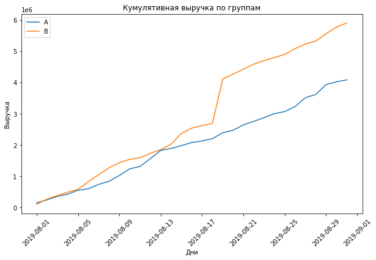

```python
# датафрейм с кумулятивным количеством заказов и кумулятивной выручкой по дням в группе А
cumulativeRevenueA = cumulativeData[cumulativeData['group']=='A'][['date','revenue', 'orders', 'visitors']]

# датафрейм с кумулятивным количеством заказов и кумулятивной выручкой по дням в группе B
cumulativeRevenueB = cumulativeData[cumulativeData['group']=='B'][['date','revenue', 'orders', 'visitors']]

# Строим график выручки группы А
plt.plot(cumulativeRevenueA['date'], cumulativeRevenueA['revenue'], label='A')

# Строим график выручки группы B
plt.plot(cumulativeRevenueB['date'], cumulativeRevenueB['revenue'], label='B')
plt.title('Кумулятивная выручка по группам')
plt.rcParams["figure.figsize"] = [10, 6]
plt.xticks(rotation=45)
plt.xlabel('Дни')
plt.ylabel('Выручка')
plt.legend()
plt.show()
```

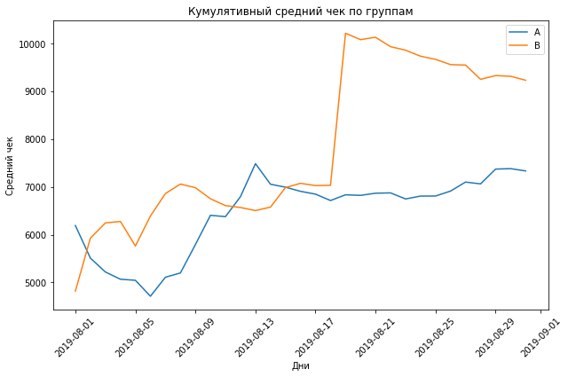

```python
plt.plot(cumulativeRevenueA['date'], cumulativeRevenueA['revenue']/cumulativeRevenueA['orders'], label='A')
plt.plot(cumulativeRevenueB['date'], cumulativeRevenueB['revenue']/cumulativeRevenueB['orders'], label='B')
plt.title('Кумулятивный средний чек по группам')
plt.xticks(rotation=45)
plt.xlabel('Дни')
plt.ylabel('Средний чек')
plt.legend()
plt.show()
```

Построим график относительного различия для среднего чека.

```python
# собираем данные в одном датафрейме
mergedCumulativeRevenue = cumulativeRevenueA.merge(cumulativeRevenueB, left_on='date', right_on='date', how='left', suffixes=['A', 'B'])
```

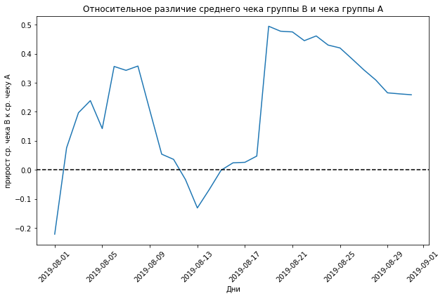

```python
# cтроим отношение средних чеков
plt.plot(mergedCumulativeRevenue['date'], (mergedCumulativeRevenue['revenueB']/mergedCumulativeRevenue['ordersB'])/(mergedCumulativeRevenue['revenueA']/mergedCumulativeRevenue['ordersA'])-1)

# добавляем ось X
plt.axhline(y=0, color='black', linestyle='--')
plt.title('Относительное различие среднего чека группы В и чека группы А')
# plt.rcParams["figure.figsize"] = [10, 6]
plt.xticks(rotation=45)
plt.xlabel('Дни')
plt.ylabel('прирост ср. чека В к ср. чеку А')
plt.show()
```

Очень резко меняется отношение средних чеков между группами в первой трети месяца, в середине и в начале третьей декады. Очевидно в данных есть выбросы.

### Конверсия по группам

Построим график кумулятивной конверсии.

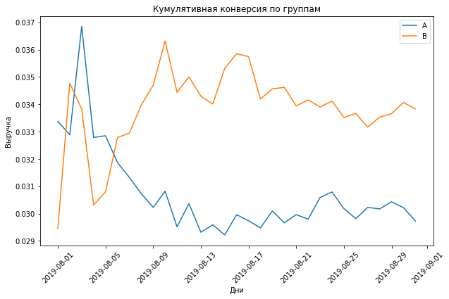

```python
# считаем кумулятивную конверсию
cumulativeData['conversion'] = cumulativeData['orders']/cumulativeData['visitors']

# отделяем данные по группе A
cumulativeDataA = cumulativeData[cumulativeData['group']=='A']

# отделяем данные по группе B
cumulativeDataB = cumulativeData[cumulativeData['group']=='B']

# строим графики
plt.plot(cumulativeDataA['date'], cumulativeDataA['conversion'], label='A')
plt.plot(cumulativeDataB['date'], cumulativeDataB['conversion'], label='B')
plt.legend()

# # задаем масштаб осей
# plt.axis(['2019-08-01','2019-08-31', 0, 0.05])
plt.title('Кумулятивная конверсия по группам')
plt.xticks(rotation=45)
plt.xlabel('Дни')
plt.ylabel('Выручка')
plt.show()
```

Конверсия группы В выросла в первой трети месяца и с некоторыми рывками постепенно снижалась. Конверсия группы А упала в начале, начала небольшой рост в середине месяца и остается низкой в конце. Оба показателя еще подвижны, но заметно преимущество группы В.

Построим график относительного различия кумулятивных конверсий:

```python
mergedCumulativeConversions = (cumulativeDataA[['date','conversion']]
.merge(cumulativeDataB[['date','conversion']], left_on='date', right_on='date', how='left', suffixes=['A', 'B']))
```

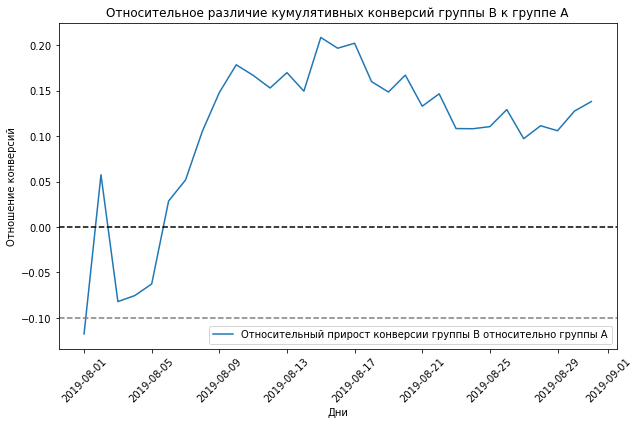

```python
plt.plot(mergedCumulativeConversions['date'],
         mergedCumulativeConversions['conversionB']/mergedCumulativeConversions['conversionA']-1,
         label="Относительный прирост конверсии группы B относительно группы A")
plt.legend()

plt.axhline(y=0, color='black', linestyle='--')
plt.axhline(y=-0.1, color='grey', linestyle='--')
plt.title('Относительное различие кумулятивных конверсий группы В к группе А')
plt.xticks(rotation=45)
plt.xlabel('Дни')
plt.ylabel('Отношение конверсий')
plt.show()
```

Конверсия группы В очень хорошо выросла относительно конверсии А в конце первой недели, с тех пор она постепенно с переменным успехом снижается. Но все равно она больше конверсии А как минимум на 10% в самой низкой точке и начала расти в конце месяца. Тут преимущество конверсии группы В очевидно.

### Анализ выбросов

#### Количество заказов на покупателя

Посмотрим распределение числа заказов на одного покупателя.

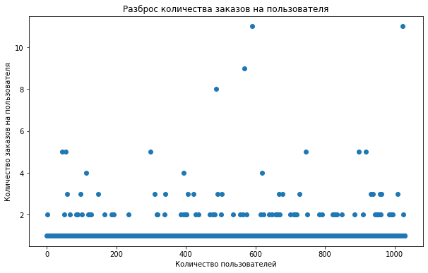

```python
# считаем количество заказов по пользователям
ordersByUsers = (
    orders.groupby('visitorId', as_index=False)
    .agg({'transactionId': 'nunique'})
)
ordersByUsers.columns = ['visitorId', 'orders']

# Построим точечную диаграмму числа заказов на одного пользователя:
x_values = pd.Series(range(0,len(ordersByUsers)))
plt.scatter(x_values, ordersByUsers['orders'])
plt.title('Разброс количества заказов на пользователя')
plt.xlabel('Количество пользователей')
plt.ylabel('Количество заказов на пользователя')
plt.show()
```

Похоже, что чаще всего покупатель делает один заказ, иногда два, редко три или больше. Чтобы точно определить границы выбросов найдем перцентили.

```python
np.percentile(ordersByUsers['orders'], [95, 99])
```

```
array([2., 4.])
```

95% покупателей делает 2 и менее заказов и только 1% делает 4 или больше заказа. Можем считать всех пользователей, кто покупает более 3-х раз, аномальными.

#### Сумма заказа

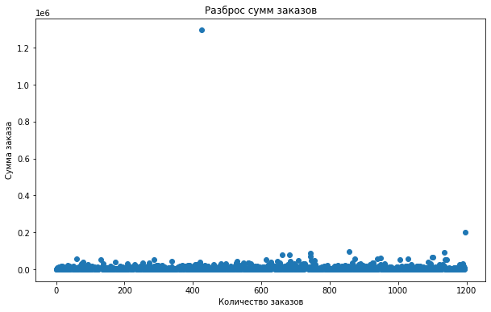

```python
# Построим точечную диаграмму сумм заказов:
x_values = pd.Series(range(0,len(orders)))
plt.scatter(x_values, orders['revenue'])
plt.title('Разброс сумм заказов')
plt.xlabel('Количество заказов')
plt.ylabel('Сумма заказа')
plt.show()
```

Мы видим, что вся масса заказов находится в диапазоне до 100000, но из-за выбросов график стал нечитаемым. Сократим размер отображаемых заказов, чтобы посмотреть более детально.

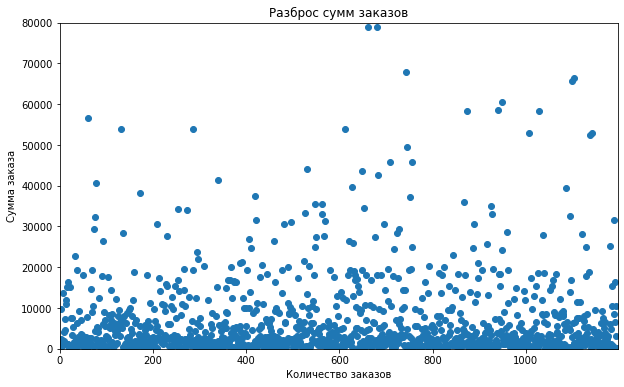

```python
# Построим точечную диаграмму сумм заказов:
x_values = pd.Series(range(0,len(orders)))
plt.scatter(x_values, orders['revenue'])
plt.title('Разброс сумм заказов')
# ограничим верхнюю границу суммы заказа, чтобы график был более подробным
plt.axis([0, len(orders), 0, 80000])
plt.xlabel('Количество заказов')
plt.ylabel('Сумма заказа')
plt.show()
```

Большая часть заказов по сумме меньше 20000. Найдем точные значения выбросов с помощью перцентилей.

```python
np.percentile(orders['revenue'], [95, 99])
```

```
array([28000. , 58233.2])
```

Только 5% заказов превышают 28000 и есть 1% заказов на суммы свыше 58000. Примем за аномальные заказы свыше 30000.

### Анализ А/В теста

#### Конверсия по сырым данным

Посчитаем количество посетителей в таблице с заказами.

```python
len(orders['visitorId'].unique())
```

```
1031
```

```python
visitorsA = orders[orders['group'] == 'A']['visitorId'].unique()
visitorsB = orders[orders['group'] == 'B']['visitorId'].unique()
print('В группе А {} посетителей, в группе В {}. В сумме {}.'.format(len(visitorsA), len(visitorsB), len(visitorsA) + len(visitorsB)))
```

```
В группе А 503 посетителей, в группе В 586. В сумме 1089.
```

Похоже, что посетители в группах действительно пересекаются, т.к. их сумма больше числа посетителей в таблице `orders`. Очистим от них датафрейм с заказами.

```python
# убираем посетителей, которые есть в обеих группах одновременно
orders = orders[~(orders['visitorId'].isin(visitorsB) & orders['visitorId'].isin(visitorsA))]
# считаем итоговое количество уникальных посетителей
len(orders['visitorId'].unique())
```

```
973
```

```python
visitorsA = orders[orders['group'] == 'A']['visitorId'].unique()
visitorsB = orders[orders['group'] == 'B']['visitorId'].unique()
print('В группе А {} посетителей, в группе В {}. В сумме {}.'.format(len(visitorsA), len(visitorsB), len(visitorsA) + len(visitorsB)))
```

```
В группе А 445 посетителей, в группе В 528. В сумме 973.
```

Очистили таблицу от посетителей, попавших в обе группы. Их стало меньше на 58.

Проверим изменилось ли количество покупателей в группе В относительно группы А. Для этого посчитаем количество покупателей в каждой группе и сравним с количеством посетителей по группам.

```python
# находим общее количество покупателей для каждой группы
orders_grouped = orders.groupby('group', as_index=False).agg(
orders = ('transactionId' , 'nunique'), buyers = ('visitorId', 'nunique'), revenue = ('revenue', 'sum')
)
orders_grouped
```

|  | group | orders | buyers | revenue |
| --- | --- | --- | --- | --- |
| 0 | A | 468 | 445 | 3364656 |
| 1 | B | 548 | 528 | 5068972 |

```python
# находим общее количество посетителей для каждой группы
visitors_gr = visitors.groupby('group')['visitors'].sum()
visitors_gr
```

```
group
A    18736
B    18916
Name: visitors, dtype: int64
```

```python
# пропорция покупателей в группе A:
p1 = orders_grouped['buyers'][0] / visitors_gr[0]
print('пропорция покупателей в группе A: {:.2%}'.format(p1))

# пропорция покупателей в группе B:
p2 = orders_grouped['buyers'][1] / visitors_gr[1]
print('пропорция покупателей в группе B: {:.2%}'.format(p2))

# пропорция покупателей в комбинированном датасете:
p_combined = (orders_grouped['buyers'][0] + orders_grouped['buyers'][1]) / (visitors_gr[0] + visitors_gr[1])
print('пропорция покупателей во всем датасете: {:.2%}'.format(p_combined))

#разница пропорций в датасетах
difference = p1 - p2
print('разница пропорций в группах: {:.2%}'.format(difference))
```

```
пропорция покупателей в группе A: 2.38%
пропорция покупателей в группе B: 2.79%
пропорция покупателей во всем датасете: 2.58%
разница пропорций в группах: -0.42%
```

Похоже, что доля покупателей в группе В выше. Проверим, можно ли считать эту разницу статистически значимой.  
Примем за нулевую гипотезу то, что доли покупателей в группах равны.  
Альтернативная гипотеза: конверсия в группах отличается.

```python
#считаем статистику в ст.отклонениях стандартного нормального распределения
z_value = difference / mth.sqrt(p_combined * (1 - p_combined) * (1/visitors_gr[0] + 1/visitors_gr[1]))

#задаем стандартное нормальное распределение (среднее 0, ст.отклонение 1)
distr = st.norm(0, 1)

alpha = .05 # критический уровень статистической значимости
p_value = (1 - distr.cdf(abs(z_value))) * 2

print('p-значение: ', p_value)

if (p_value < alpha):
    print("Отвергаем нулевую гипотезу: между долями есть значимая разница")
else:
    print("Не получилось отвергнуть нулевую гипотезу, нет оснований считать доли разными")
```

```
p-значение:  0.01093208956553604
Отвергаем нулевую гипотезу: между долями есть значимая разница
```

```python
print('Конверсия группы В больше конверсии группы А на {:.2%}'.format(p2/p1 - 1 ))
```

```
Конверсия группы В больше конверсии группы А на 17.52%
```

#### Средний чек по сырым данным

Посчитаем средние чеки по группам и сравним их.

```python
# считаем средние чеки
print('Средний чек по группе В:', round(orders[orders['group']=='B']['revenue'].mean()))
print('Средний чек по группе A:', round(orders[orders['group']=='A']['revenue'].mean()))
# считаем относительные различия:
print('Средний чек группы В превышает средний чек группы А на {0:.1%}'.format(orders[orders['group']=='B']['revenue'].mean()/orders[orders['group']=='A']['revenue'].mean()-1))
```

```
Средний чек по группе В: 9250
Средний чек по группе A: 7189
Средний чек группы В превышает средний чек группы А на 28.7%
```

Неплохой результат, похоже, что средний чек хорошо вырос. По крайней мере по неочищенным от выбросов данным.  
Проверим статзначимость этих различий с помощью теста Манна-Уитни.

Проверяем отличаются ли средние чеки двух групп. Если полученный параметр будет в пределах выбранного значения статзначимости, то мы сможем отбросить нулевую гипотезу.  
Нулевая гипотеза: средние значения двух выборок равны,  
альтернативная: средние двух выборок отличаются.  
Значение стат значимости α = 0,05.

```python
print('P-value равно {0:.3f}.'.format(st.mannwhitneyu(orders[orders['group']=='A']['revenue'],
                       orders[orders['group']=='B']['revenue'])[1]))
```

```
P-value равно 0.829.
```

P-value очень высоко, при таком значении мы не можем отбросить гипотезу о равенстве средних чеков, несмотря на сравнение абсолютных величин. Видимо на них сильно отразились очень высокие суммы нетипичных заказов.

#### Конверсия по очищенным данным

```python
# выделяем покупателей с большим количеством заказов
usersWithManyOrders = ordersByUsers[ordersByUsers['orders'] > 3]['visitorId']
# выделяем покупателей с крупными заказами
usersWithExpensiveOrders = orders[orders['revenue'] > 30000]['visitorId']
# соединяем списки
abnormalUsers = (
    pd.concat([usersWithManyOrders, usersWithExpensiveOrders], axis=0)
    .drop_duplicates()
    .sort_values()
)
print(abnormalUsers.head(5))
print(abnormalUsers.shape[0])
```

```
1099    148427295
44      199603092
928     204675465
55      237748145
684     358944393
Name: visitorId, dtype: int64
55
```

Мы выделили список нетипичных покупателей, их получилось 55 из общего числа покупателей 973.

```python
# убираем нетипичных покупателей
orders_filtered = orders[~orders['visitorId'].isin(abnormalUsers)]
print('Удалили из таблицы orders', len(orders) - len(orders_filtered), 'строк.')
```

```
Удалили из таблицы orders 43 строк.
```

Посчитаем конверсию по группам на очищенных данных.

```python
# находим общее количество покупателей для каждой группы
orders_grouped_f = orders_filtered.groupby('group', as_index=False).agg(
orders_filtered = ('transactionId' , 'nunique'), buyers = ('visitorId', 'nunique'), revenue = ('revenue', 'sum')
)
orders_grouped_f
```

|  | group | orders_filtered | buyers | revenue |
| --- | --- | --- | --- | --- |
| 0 | A | 448 | 426 | 2385548 |
| 1 | B | 525 | 505 | 2709781 |

```python
# общее количество посетителей для каждой группы мы уже считали
visitors_gr
```

```
group
A    18736
B    18916
Name: visitors, dtype: int64
```

```python
# пропорция покупателей в группе A:
p1 = orders_grouped_f['buyers'][0] / visitors_gr[0]
print('пропорция покупателей в группе A: {:.2%}'.format(p1))

# пропорция покупателей в группе B:
p2 = orders_grouped_f['buyers'][1] / visitors_gr[1]
print('пропорция покупателей в группе B: {:.2%}'.format(p2))

# пропорция покупателей в комбинированном датасете:
p_combined = (orders_grouped_f['buyers'][0] + orders_grouped_f['buyers'][1]) / (visitors_gr[0] + visitors_gr[1])
print('пропорция покупателей во всем датасете: {:.2%}'.format(p_combined))

#разница пропорций в датасетах
difference = p1 - p2
print('разница пропорций в группах: {:.2%}'.format(difference))
```

```
пропорция покупателей в группе A: 2.27%
пропорция покупателей в группе B: 2.67%
пропорция покупателей во всем датасете: 2.47%
разница пропорций в группах: -0.40%
```

Конверсия в группе В несколько выше. Посчитаем статистику в стандартных отклонениях стандартного нормального распределения. Нулевая гипотеза: конверсии групп равны, альтернативная: конверсии отличаются.

```python
#считаем статистику в ст.отклонениях стандартного нормального распределения
z_value = difference / mth.sqrt(p_combined * (1 - p_combined) * (1/visitors_gr[0] + 1/visitors_gr[1]))

#задаем стандартное нормальное распределение (среднее 0, ст.отклонение 1)
distr = st.norm(0, 1)

alpha = .05 # критический уровень статистической значимости
p_value = (1 - distr.cdf(abs(z_value))) * 2

print('p-значение: ', p_value)

if (p_value < alpha):
    print("Отвергаем нулевую гипотезу: между конверсиями есть значимая разница")
else:
    print("Не получилось отвергнуть нулевую гипотезу, нет оснований считать конверсии разными")
```

```
p-значение:  0.013358748838567358
Отвергаем нулевую гипотезу: между конверсиями есть значимая разница
```

```python
print('Конверсия группы В больше конверсии группы А на {:.2%}'.format(p2/p1 - 1 ))
```

```
Конверсия группы В больше конверсии группы А на 17.42%
```

#### Средний чек по очищенным данным

Посчитаем средние чеки по группам и сравним их.

```python
# считаем средние чеки
print('Средний чек по группе В:', round(orders_filtered[orders_filtered['group']=='B']['revenue'].mean()))
print('Средний чек по группе A:', round(orders_filtered[orders_filtered['group']=='A']['revenue'].mean()))
# считаем относительные различия:
print('Средний чек группы В превышает средний чек группы А на {0:.1%}'.format(orders_filtered[orders_filtered['group']=='B']['revenue'].mean()/orders_filtered[orders_filtered['group']=='A']['revenue'].mean()-1))
```

```
Средний чек по группе В: 5161
Средний чек по группе A: 5325
Средний чек группы В превышает средний чек группы А на -3.1%
```

После того как мы убрали нетипичных покупателей, средний чек по группе В стал меньше среднего чека по группе А на 3,1%.  
Проверим статзначимость этих различий с помощью теста Манна-Уитни.

Нулевая гипотеза: средние чеки двух выборок равны,  
альтернативная: средние чеки двух выборок отличаются.  
Значение стат значимости α = 0,05.

```python
print('р-value равно {0:.3f}.'.format(st.mannwhitneyu(orders_filtered[orders_filtered['group']=='A']['revenue'],
                       orders_filtered[orders_filtered['group']=='B']['revenue'])[1]))
```

```
р-value равно 0.842.
```

После очистки данных р-значение стало ещё выше, а средний чек группы В оказался меньше среднего чека группы А, но не значительно, разница около 3%. А значит, мы не можем утверждать, что в группе В чек отличается от среднего чека группы А.

### Анализ А/В теста после очистки данных

#### График кумулятивной выручки и среднего чека

Построим заново графики кумулятивной выручки на очищенных данных.

```python
# получаем агрегированные кумулятивные по дням данные о заказах
ordersAggregated = (df.apply(lambda x: orders_filtered[(orders_filtered['date'] <= x['date']) &
                                               (orders_filtered['group'] == x['group'])].agg(
    {'date' : 'max', 'group' : 'max', 'transactionId' : 'nunique', 'visitorId' : 'nunique', 'revenue' : 'sum'}), axis=1)
    .sort_values(by=['date','group']))

# получаем агрегированные кумулятивные по дням данные о посетителях интернет-магазина
visitorsAggregated = (df.apply(lambda x: visitors[(visitors['date'] <= x['date']) &
                                                          (visitors['group'] == x['group'])]
                                    .agg({'date' : 'max', 'group' : 'max', 'visitors' : 'sum'}), axis=1)
                                    .sort_values(by=['date','group']))

# объединяем кумулятивные данные в одной таблице и присваиваем ее столбцам понятные названия
cumulativeData = ordersAggregated.merge(visitorsAggregated, left_on=['date', 'group'], right_on=['date', 'group'])
cumulativeData.columns = ['date', 'group', 'orders', 'buyers', 'revenue', 'visitors']
```

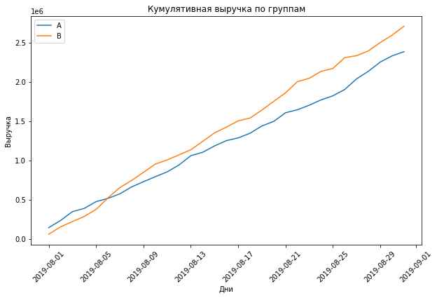

```python
# датафрейм с кумулятивным количеством заказов и кумулятивной выручкой по дням в группе А
cumulativeRevenueA = cumulativeData[cumulativeData['group']=='A'][['date','revenue', 'orders', 'visitors']]

# датафрейм с кумулятивным количеством заказов и кумулятивной выручкой по дням в группе B
cumulativeRevenueB = cumulativeData[cumulativeData['group']=='B'][['date','revenue', 'orders', 'visitors']]

# Строим график выручки группы А
plt.plot(cumulativeRevenueA['date'], cumulativeRevenueA['revenue'], label='A')

# Строим график выручки группы B
plt.plot(cumulativeRevenueB['date'], cumulativeRevenueB['revenue'], label='B')
plt.title('Кумулятивная выручка по группам')
plt.xticks(rotation=45)
plt.xlabel('Дни')
plt.ylabel('Выручка')
plt.legend()
plt.show()
```

Выручка группы В начала опережать выручку группы А уже через неделю и с тех пор увеличивает разрыв.  
Построим графики среднего чека по группам — разделим кумулятивную выручку на кумулятивное число заказов.

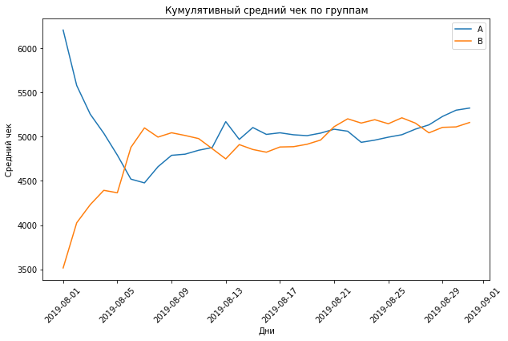

```python
plt.plot(cumulativeRevenueA['date'], cumulativeRevenueA['revenue']/cumulativeRevenueA['orders'], label='A')
plt.plot(cumulativeRevenueB['date'], cumulativeRevenueB['revenue']/cumulativeRevenueB['orders'], label='B')
plt.title('Кумулятивный средний чек по группам')
plt.xticks(rotation=45)
plt.xlabel('Дни')
plt.ylabel('Средний чек')
plt.legend()
plt.show()
```

Средние чеки в группах попеременно обгоняют друг друга, можно сказать, что они сближаются в районе 5200-5300.

Построим график относительного различия для среднего чека.

```python
# собираем данные в одном датафрейме
mergedCumulativeRevenue = cumulativeRevenueA.merge(cumulativeRevenueB, left_on='date', right_on='date', how='left', suffixes=['A', 'B'])
```

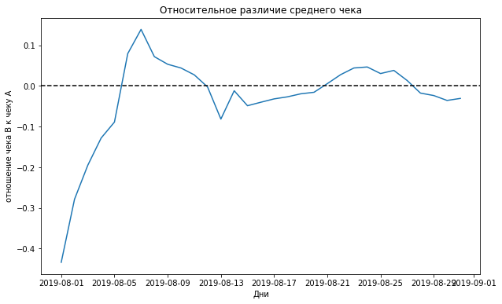

```python
# cтроим отношение средних чеков
plt.plot(mergedCumulativeRevenue['date'], (mergedCumulativeRevenue['revenueB']/mergedCumulativeRevenue['ordersB'])/(mergedCumulativeRevenue['revenueA']/mergedCumulativeRevenue['ordersA'])-1)

# добавляем ось X
plt.axhline(y=0, color='black', linestyle='--')
plt.title('Относительное различие среднего чека')
plt.xlabel('Дни')
plt.ylabel('отношение чека В к чеку А')
plt.show()
```

#### График кумулятивной конверсии

Построим график кумулятивной конверсии.

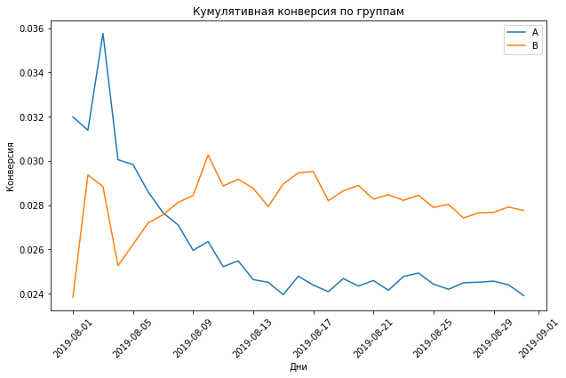

```python
# считаем кумулятивную конверсию
cumulativeData['conversion'] = cumulativeData['orders']/cumulativeData['visitors']

# отделяем данные по группе A
cumulativeDataA = cumulativeData[cumulativeData['group']=='A']

# отделяем данные по группе B
cumulativeDataB = cumulativeData[cumulativeData['group']=='B']

# строим графики
plt.plot(cumulativeDataA['date'], cumulativeDataA['conversion'], label='A')
plt.plot(cumulativeDataB['date'], cumulativeDataB['conversion'], label='B')
plt.legend()
plt.title('Кумулятивная конверсия по группам')
plt.xticks(rotation=45)
plt.xlabel('Дни')
plt.ylabel('Конверсия')
# # задаем масштаб осей
# plt.axis(['2019-08-01','2019-08-31', 0, 0.05])
plt.show()
```

Конверсия группы В выросла в начале месяца и обогнала конверсию группы А уже в первую неделю и с тех пор более-менее стабильно находится в районе 2,8%. Конверсия группы А снизилась к середине августа до 2,4% и продолжает оставаться на этом уровне.  
Конверсия группы В стабильно лучше конверсии группы А по очищенным данным.

Построим график относительного различия кумулятивных конверсий:

```python
mergedCumulativeConversions = (cumulativeDataA[['date','conversion']]
.merge(cumulativeDataB[['date','conversion']], left_on='date', right_on='date', how='left', suffixes=['A', 'B']))
```

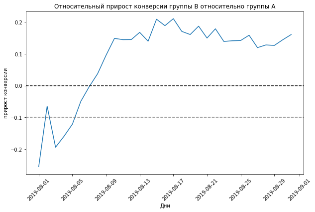

```python
plt.plot(mergedCumulativeConversions['date'],
         mergedCumulativeConversions['conversionB']/mergedCumulativeConversions['conversionA']-1)

plt.title("Относительный прирост конверсии группы B относительно группы A")
plt.xticks(rotation=45)
plt.xlabel('Дни')
plt.ylabel('прирост конверсии')
plt.axhline(y=0, color='black', linestyle='--')
plt.axhline(y=-0.1, color='grey', linestyle='--')
plt.show()
```

Конверсия группы В очень хорошо обогнала группу А к середине месяца, на 15-20%, чуть снизилось их соотношение к концу, но все равно она больше конверсии А как минимум на 10%.  
Преимущество конверсии группы В очевидно и на очищенных данных.

## **Вывод**

При анализе в данных мы обнаружили нетипично высокие заказы, а также покупателей с количеством покупок больше нормального. Эти покупки выразились в резком росте среднего чека в группе В в середине месяца. Чтобы исключить их влияние на результаты теста мы очистили данные от покупателей с 4 и более заказами, а также тех, кто покупал на суммы свыше 30000. Это 55 покуателей из тысячи.  
Также пришлось убрать из анализа данные 58 покупателей, которые попали в обе группы.  
В результате анализа А/В теста мы можем утверждать, что средняя конверсия группы В (2,67%) выше конверсии группы А (2,27%) на 17%. Средний чек в группе В (5161) не настолько отличается о чека группы А (5325) чтобы считать это отличие статистически значимым.  
При более высокой конверсии и одинаковом среднем чеке покупатели группы В приносят больше выручки чем покупатели группы А, что можно видеть на графике кумулятивной выручки.  
Думаю, что тест можно остановить и зафиксировать преимущество группы В.